# My R code is slow

Slides: [jumpingrivers.com]

## Who am I

- Dr Colin Gillespie
  - Originally from the 1990 City of Culture (Glasgow)
  - Senior Statistics Lecturer, Newcastle University
  - Consultant at Jumping Rivers
  - twitter: csgillespie
  - [linkedin](https://uk.linkedin.com/in/colin-gillespie-25028332)

## Jumping Rivers

- Statistical and R consultancy
- R, Scala, python, & Stan training
- Predictive analytics
- Dashboard development
- Questionnaires

## My R code is slow

## Use the byte compiler!

## Byte compiler

- The compiler package has been part of R since version 2.13.0
  - It translates R functions into another language that can be interpreted by a very fast interpreter
- Since R 2.14.0, all of the standard functions and packages in R will be pre-compiled into byte-code

## Byte compiler: the mean() function

```
#> function (x, ...)
#> UseMethod("mean")
#> <bytecode: 0x73098b8>
#> <environment: namespace:base>
```

note the `bytecode` line

## Byte compiler

- We can compile our own R functions and obtain byte code version that may run faster.

## Example: Bad mean

```r
mean_r = function(x) {
  total = 0
  n = length(x)
  for(i in 1:n)
    total = total + x[i]/n
  total
}
```

## Compiled version

```r
library("compiler")
cmp_mean_r = cmpfun(mean_r)
cmp_mean_r
```

```
#> function(x) {
#>   total = 0
#>   n = length(x)
#>   for(i in 1:n)
#>     total = total + x[i]/n
#>   total
#> }
#> <bytecode: 0x5608fa8>
```

## Benchmarks

```r
# Generate some data
x = rnorm(1000)
microbenchmark::microbenchmark(times = 10, unit = "ms", # milliseconds
          mean_r(x), cmp_mean_r(x), mean(x))
```

```
#> Unit: milliseconds
#>           expr   min    lq  mean median    uq  max neval cld
#>      mean_r(x) 0.358 0.361 0.370  0.363 0.367 0.43    10   c
#>  cmp_mean_r(x) 0.050 0.051 0.052  0.051 0.051 0.07    10  b
#>        mean(x) 0.005 0.005 0.008  0.007 0.008 0.03    10 a
```

## Benchmarks

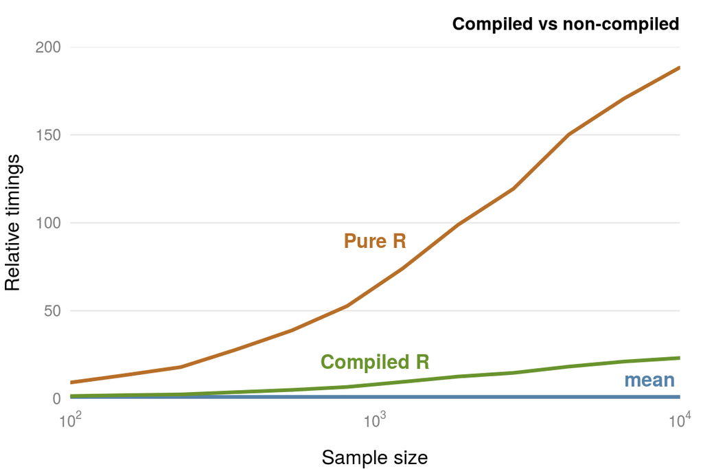

## Compiling code

There are a number of ways to complile code.

## Compiling code

- Most R packages installed using `install.packages()` are not compiled
  - We can force packages to be compiled by starting R with the environment variable `R_COMPILE_PKGS`
  - Add `R_COMPILE_PKGS=3` to `~/.Renviron`

## Compiling packages

```r
## Windows users need Rtools
install.packages("ggplot2",
                 type = "source",
                 INSTALL_opts = "--byte-compile")
```

## My R code is slow

## Change your BLAS library

## Basic Linear Algebra System (BLAS)

- R uses BLAS for linear algebra operations
  - Anything involving matrices
- By switching to a different BLAS library, it may be possible to speed-up your R code.
  - Easy for Linux/Apple, but can be tricky for Windows users
- Two open source alternative BLAS libraries are ATLAS and OpenBLAS.

## Issues

- ATLAS and OpenBLAS use multiple cores
  - Occassionally this can be a problem (if it's embedded in a parallel problem)

## A quick break

```r
install.packages("benchmarkme")
```

## My R code is slow

## Buy a better computer!

## Or should you?

## `benchmarkme`

```r
library("benchmarkme")
```

```r
get_ram()
```

```
#> 16.3 GB
```

```r
get_cpu()
```

```
#> $vendor_id
#> [1] "GenuineIntel"
#>
#> $model_name
#> [1] "Intel(R) Core(TM) i7-4702HQ CPU @ 2.20GHz"
#>
#> $no_of_cores
#> [1] 8
```

## `benchmarkme`

```r
library("benchmarkme")## On CRAN
## Tests based on a script by
## Simon Urbanek & Douglas Bates
res = benchmark_std(runs = 3)
```

## `benchmarkme`

```r
library("benchmarkme")
res = benchmark_std(runs = 2)
# # Programming benchmarks (5 tests):
#     3,500,000 Fibonacci numbers calculation (vector calc): 0.52 (sec).
#     Grand common divisors of 1,000,000 pairs (recursion): 0.965 (sec).
#     Creation of a 3500x3500 Hilbert matrix (matrix calc): 0.306 (sec).
#     Creation of a 3000x3000 Toeplitz matrix (loops): 11.5 (sec).
#     Escoufier's method on a 60x60 matrix (mixed): 1.17 (sec).
# # Matrix calculation benchmarks (5 tests):
#    Creation, transp., deformation of a 5000x5000 matrix: 0.794 (sec).
#    2500x2500 normal distributed random matrix ^1000: 0.522 (sec).
#    Sorting of 7,000,000 random values: 0.598 (sec).
#    2500x2500 cross-product matrix (b = a' * a): 6.56 (sec).
#    Linear regr. over a 3000x3000 matrix (c = a \ b'): 4.5 (sec).
# # Matrix function benchmarks (5 tests):
```

## `benchmarkme`

```r
# Upload results +
# RAM, CPU,
# OS, byte-compile, BLAS
upload_results(res)
```

## `benchmarkme`

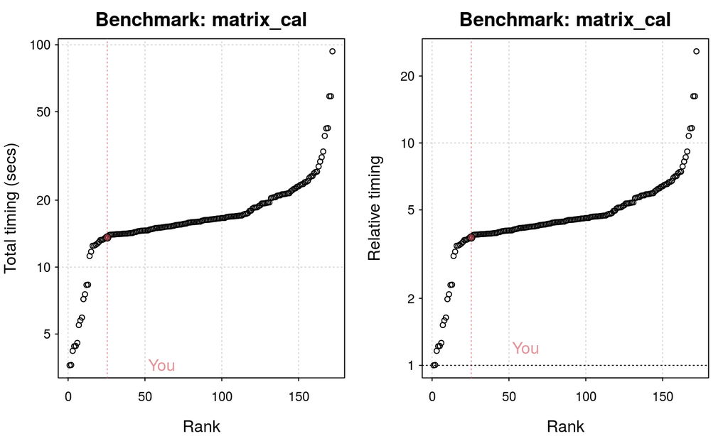

```r
plot(res)
```

## Uploaded results

## Hardware: RAM

## Results: Programming benchmarks

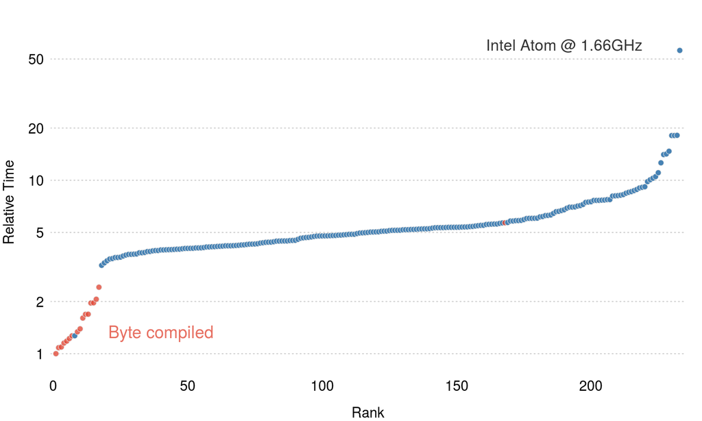

[figure not shown]

## Results: Matrix benchmarks

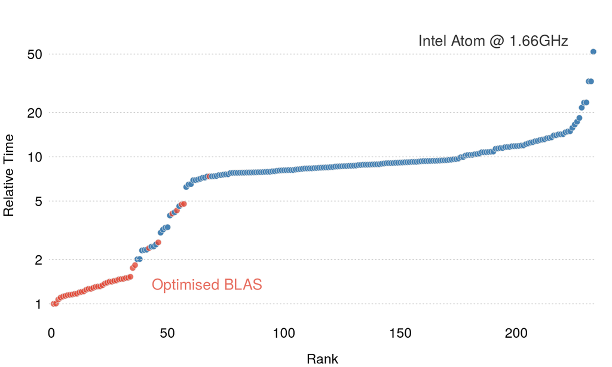

## Intel CPU Differences (relative times)

## Input/output `benchmark_io`

## Adding benchmarkme to your package

- `upload_results` takes a five column matrix
  - Columns 1 to 3: `system.time` output
  - Columns 4 & 5 are benchmark labels
- Easy to add to your own package
  - Results will be automatically incorparated in future `benchmarkme` releases

## Summary

- Upgrade hardware
- Byte-compiling and BLAS are easy optimisations
  - No-one byte compiles!
- Network drives are slow

## Links

- Efficient R [programming](https://csgillespie.github.io/efficientR)
  - Chapter 2: [BLAS](https://csgillespie.github.io/efficientR/efficient-set-up.html#blas-and-alternative-r-interpreters)
  - chapter 7: [byte compiling](https://csgillespie.github.io/efficientR/programming.html#the-byte-compiler)
  - Chapter 8: General [hardware](https://csgillespie.github.io/efficientR/hardware.html) advice
- Additional 10% discount for any course booked before Jan 2017
  - Just mention `@edinbR` in the booking form